# Natality Models

May 9, 2016

## Agenda

- Research Question
- Data Sets
- Methodology
- Models
- Results

## Research Question

Using national aggregate data, how can the number of births be forecast? What factors are significant predictors of births in the United States?

## Why is this important?

-Having a glimpse into a society's future population size and demographics can give governments (and private companies) insight into things that need to be done to keep things running efficiently

- In the case of a private company it may illuminate new business areas and profit opportunities

## Data Sets

- Natality, 2007-2014
- Natality, 2003-2006
- Women's Earnings 2003-2014 - Current Population Survey
- Unemployment Rates 2003-2015
- Census Estimates 2000-2010
- Census Estimates 2010-2015

[figure not shown]

## Methodology

- Data Tidying
- Joining Data
- Exploration
- Building Models
- Selecting Model(s)

## Methodology - Data Tidying

- Census Data
- 2000-2010: Only Total Population
- 2010-2015: Broken down by Age and Gender

## Methodology - Gender Bins

\[ G_{year} = \frac{F_{year}}{P_{year}} \]

\[ F_{month} = P_{month} * G_{year} \]

\[ M_{month} = P_{month} - F_{month} \]

Where:

\(\quad G \quad \text{Gender Ratio}\)

\(\quad F \quad \text{Total females, TOT_FEMALE} \)

\(\quad M \quad \text{Total males, TOT_MALE} \)

\(\quad P \quad \text{Total population, TOT_POP} \)

## Methodology: Age Bins

\[F_{year\_x\_y} = \sum_{i=x}^{y-1} F_{year\_i}\]

\[ A_{year\_x\_y} = \frac{F_{year\_x\_y}}{F_{year}} \]

\[ F_{month\_x\_y} = F_{month} * A_{year\_x\_y} \]

Where:

\(\quad x \quad \text{Lower age bound of bin} \)

\(\quad y \quad \text{Upper age bound of bin} \)

\(\quad A \quad \text{Age bin's ratio} \)

## Model Data

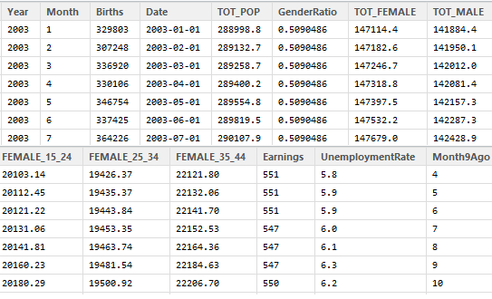

## Methodology: Year over Year Birth Rates

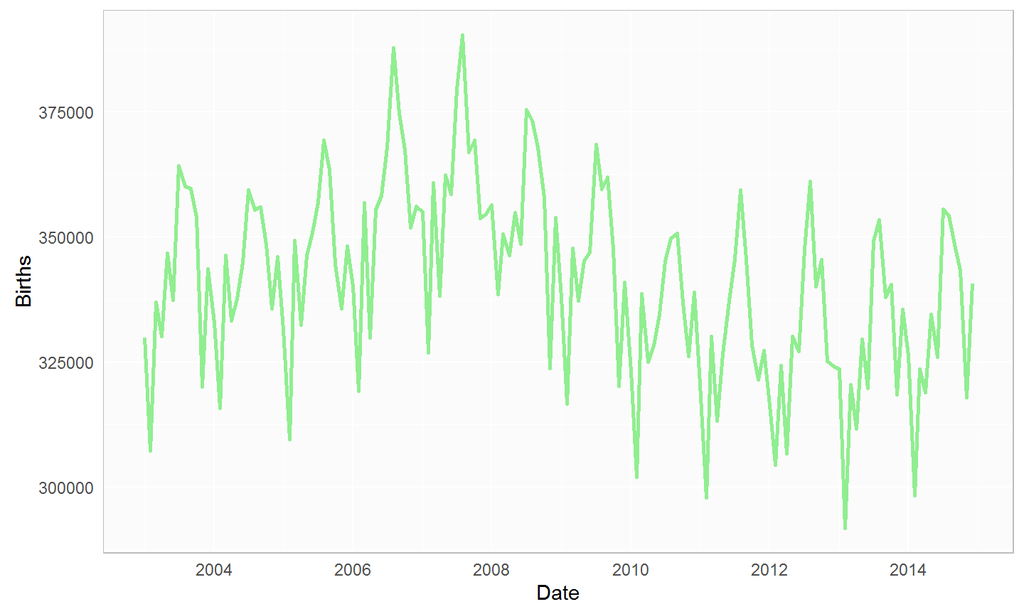

## Methodology: Birth Rates By Month

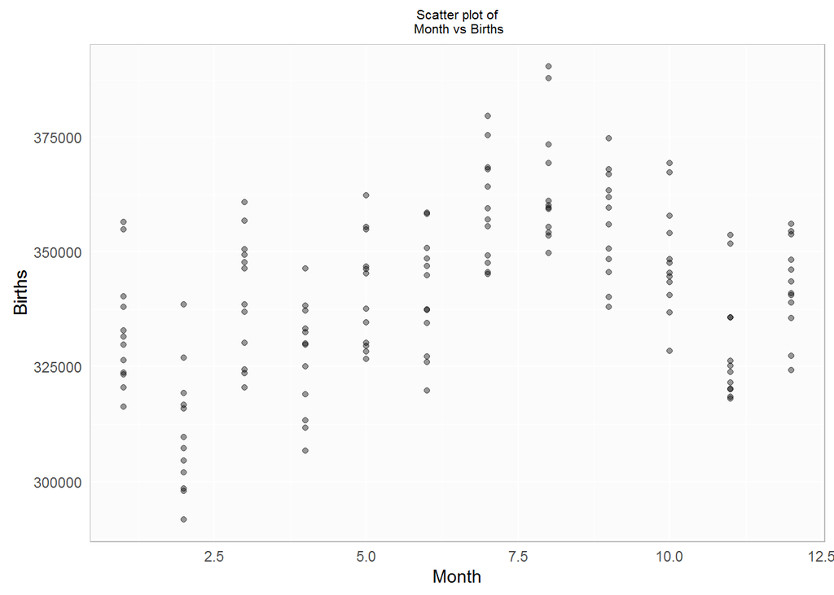

## Models

| Model | VS Error | Adj R^2 | AIC | Variables | VIF |
| --- | --- | --- | --- | --- | --- |
| All Variables | 161072343 | 0.6112935 | 2504.690 | 11 | BAD |
| Neg Binomial Step | 161290241 | NA | 2506.956 | 10 | BAD |
| Poisson Step | 161316049 | NA | 40569.475 | 10 | BAD |
| Step | 172024296 | 0.6200088 | 2497.456 | 5 | BAD |
| Poisson Signif Ltd | 176055186 | NA | 51551.445 | 4 | OK |
| Significant Limited | 176416016 | 0.5258888 | 2522.176 | 4 | OK |
| Signif Ltd w/ Interaction | 177767094 | 0.5218164 | 2524.118 | 5 | BAD |
| High Cor | 212269346 | 0.4788873 | 2535.031 | 6 | BAD |
| Significant | 227028994 | 0.4771385 | 2536.351 | 7 | BAD |
| Significant Minus | 231634851 | 0.3600735 | 2557.915 | 5 | BAD |

## Models: Significant Limited

Significant Variables Limited Linear Model Coefficient Estimates

|  | Estimate | Pr(>\|t\|) |
| --- | --- | --- |
| Intercept * | 468350.706460 | 0.0000000 |
| Month * | 2490.804603 | 0.0000000 |
| Month9Ago * | 2649.171132 | 0.0000000 |
| FEMALE_25_34 * | -7.181586 | 0.0003757 |
| UnemploymentRate * | -2190.844273 | 0.0030120 |

## Models

The Significant Limited model has an F-statistic of 32.89 and a mean squared error (MSE) of 146358133.79.

\[ \begin{array}{llll} y_{births} = & 468350.7064601 & +2490.8046026 x_{Month} & \\ & & + 2649.1711324 x_{Month9Ago} & \\ & & -7.181586 x_{FEMALE\_25\_34} & \\ & & -2190.8442727 x_{UnemploymentRate} & \end{array} \]

We can interpret the coefficients in the following manner. Holding all other predictors constant, for variable:

- *Month*, as the month of the year increased, a \(2490.8\) increase in births would occur.
- *Month9Ago*, as the 9 month lagged month of the year increased, a \(2649.17\) increase in births would occur.
- *FEMALE_25_34*, a unit increase in the population of females age 25-34 would yield a \(7.18\) decrease in births.
- *UnemploymentRate*, a unit increase in the *UnemploymentRate* related to a \(2190.84\) decrease in births.

## Results: Diagnostics

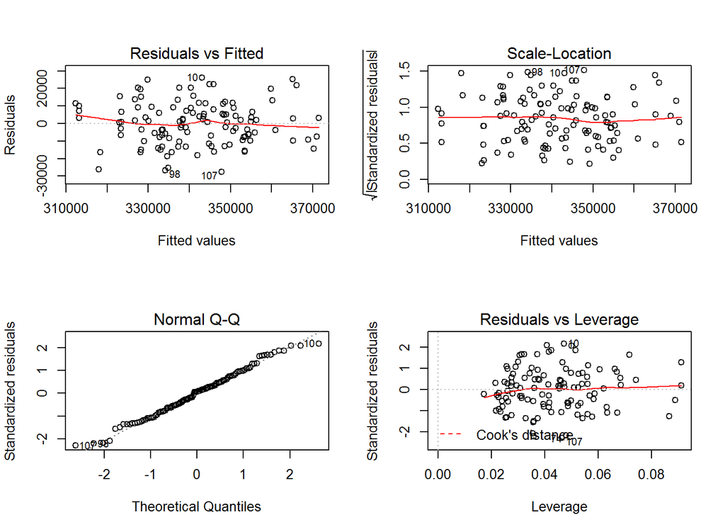

## Results: Inverse Response Plot

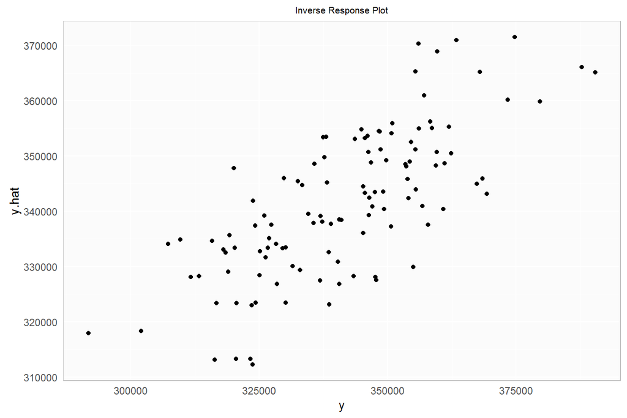

## Results

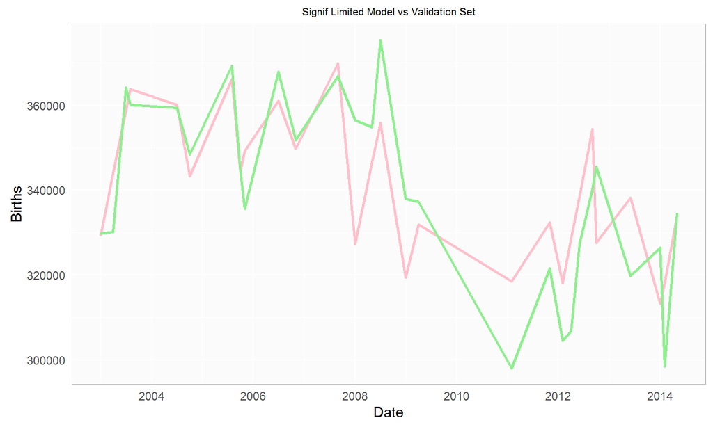

- Red = Model
- Green = Actual

## Conclusions

- Reasonable for the time period studied
- Changepoint during recession?
- Other independent variables we aren't including?
- Further validation against historical data, 1980s, 1990s?

## Thank you!

- Questions?